# SARS-CoV-2

Vladislav Mozgovoy

11/22/2020

### Цели :

#### О данных :

Данные используемые в данной работе взяты с сайта Национального центра биотехнической информации США [NCBI](https://www.ncbi.nlm.nih.gov/) в разделе посвященном [SARS CoV 2](https://www.ncbi.nlm.nih.gov/sars-cov-2/). Все данные представлены в формате .fasta

#### Скачивание:

Последовательности SARS-CoV-2 для следующих стран: USA (MT982401.1), Egypt (MW250352.1), India (MW242950.1), Phillipines (MW243995.1), Peru (MW185823.1), Israel (MW237708.1), China (MT412338.1), United Kingdom (MW255832.1), Germany (MT845877.1), а также SARS-CoV-1 (AY394995.1), все последовательности были взяты с NCBI

### Обработка:

##### Построение деревьев

Выровнием последовательности алгоритмом Muscle с cluster method: UPGMA, получим [выровненные последовательности](https://drive.google.com/file/d/1kc6_OVghl_PA2pgcyYUtXgKXkGD4Fk4z/view?usp=drivesdk) Далее построим деревья различными методами – Maximum Likelihood(ML), Neighbor Joining(NJ), Maximum Parsimony, UPGMA.

[ML](https://drive.google.com/file/d/1pj5pk_VupiLs5DvEZbg0DwibLgN7KF1O/view?usp=sharing)

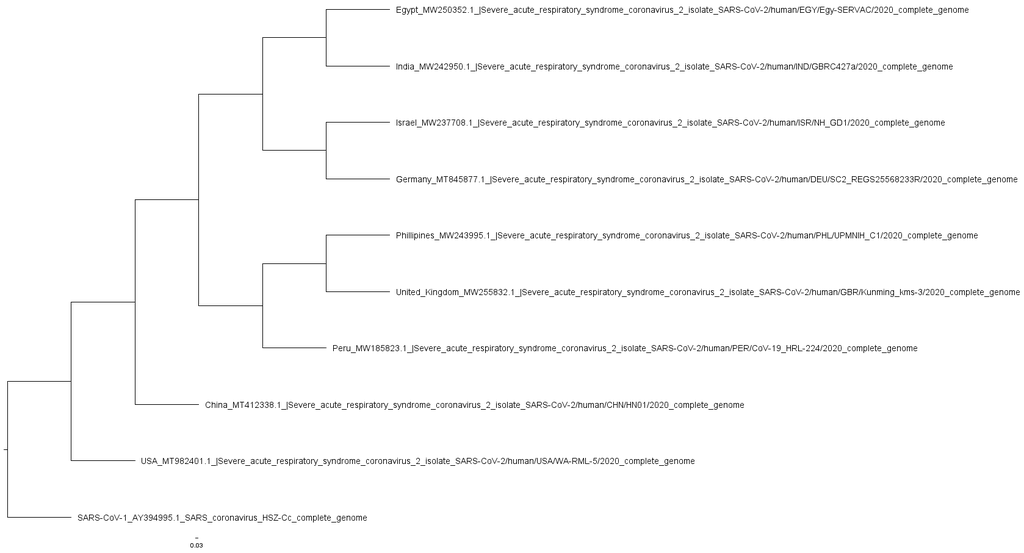

Заметим, что самые близкие(то есть те, кто заразился раньше других) к SARS-CoV-1 это USA и China, а самый дальний Egypt, следовательно он заразился позже всех(в данной выборке)

[NJ](https://drive.google.com/file/d/1m5s4RSjhooZOTgGQODUzSeaA-_yvdfao/view?usp=sharing)

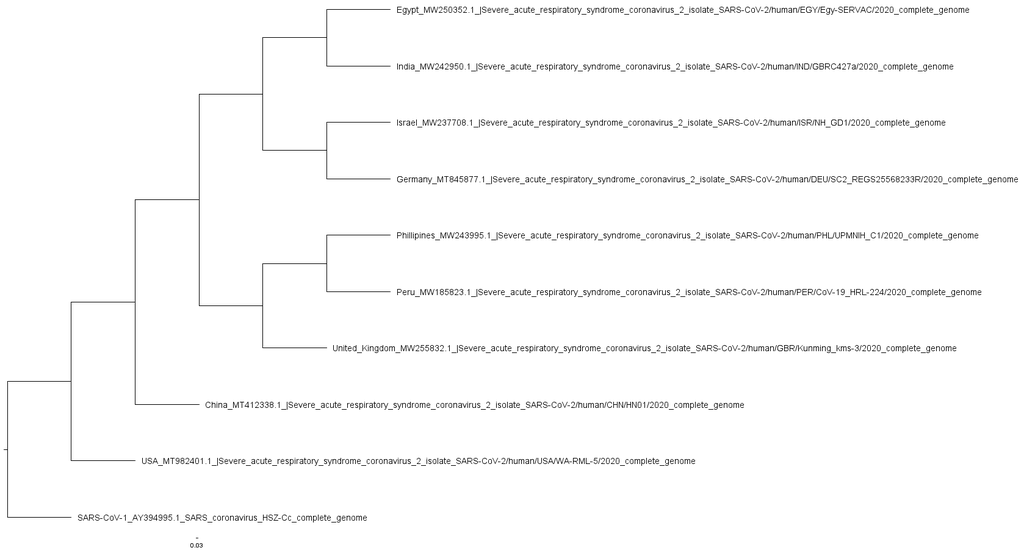

Заметим, что самые близкие к SARS-CoV-1 это USA и China, а самый дальний Egypt

[Parsimony](https://drive.google.com/file/d/1gj83R-Yx7gq2PcGx3TTt_cuX0pZLoi_o/view?usp=sharing)

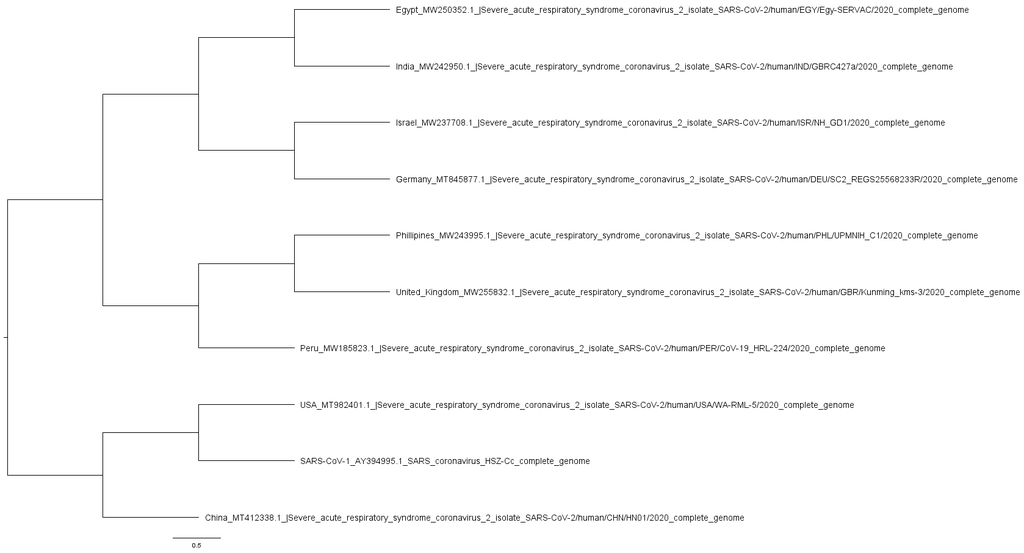

Заметим, что самые близкие к SARS-CoV-1 это USA и China, а самый дальний Egypt

[UPGMA](https://drive.google.com/file/d/16cfLCQ_qS2v30Bkto0Tmph146sbW9ZJr/view?usp=sharing)

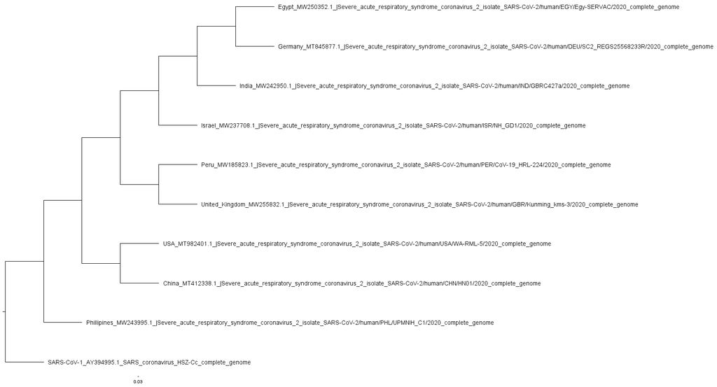

Заметим, что самые близкие к SARS-CoV-1 это Phillipines и China, а самый дальний Egypt

#### Поиск различий

Отдельно рассмотрим пары из самой ближне и самой дальней страны в дереве, то есть USA и Egypt для ML,NJ,Parsimony и Phillipines и Egypt для UPGMA. Для повышения точности выровнием отдельно эти пары стран, а затем выделим мутации, выбрав в mega x: toggle conserved sites 100%.

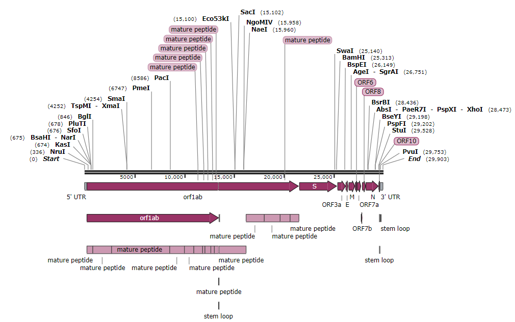